# Using the `stormwindmodel` package

## Overview

The `stormwindmodel` package was created to allow users to model wind speeds at grid points around the world based on “best tracks” hurricane tracking data, using a model for wind speed developed by Willoughby and coauthors (2006). The package includes functions for interpolating hurricane tracks and for modeling and mapping wind speeds during the storm. For the US, it includes population mean center locations for all counties, which can be used to map winds by county; however, other grid point locations can also be input for modeling, either to model at other resolutions in the US or to model in other locations around the world. Full details on how this model is fit are provided in the “Details” vignette of the `stormwindmodel` package.

## Package example data

For examples in this vignette, the package includes data on the tracks of Hurricane Floyd in 1999 and Hurricane Katrina in 2005 (other vignettes show examples from outside the US, including in Australia and China). You can load these example best tracks data sets using:

```r
library(stormwindmodel)
data("floyd_tracks")
head(floyd_tracks)
```

```
## # A tibble: 6 × 4
##   date         latitude longitude  wind
##   <chr>           <dbl>     <dbl> <dbl>
## 1 199909071800     14.6     -45.6    25
## 2 199909080000     15       -46.9    30
## 3 199909080600     15.3     -48.2    35
## 4 199909081200     15.8     -49.6    40
## 5 199909081800     16.3     -51.1    45
## 6 199909090000     16.7     -52.6    45
```

```r
data("katrina_tracks")
head(katrina_tracks)
```

```
## # A tibble: 6 × 4
##   date         latitude longitude  wind
##   <chr>           <dbl>     <dbl> <dbl>
## 1 200508231800     23.1     -75.1    30
## 2 200508240000     23.4     -75.7    30
## 3 200508240600     23.8     -76.2    30
## 4 200508241200     24.5     -76.5    35
## 5 200508241800     25.4     -76.9    40
## 6 200508250000     26       -77.7    45
```

This example data includes the following columns:

- `date`: Date and time of the observation (in the UTC time zone, which is usually used for best tracks data from sources like IBTrACS)
- `latitude`, `longitude`: Location of the storm at that time
- `wind`: Maximum sustained wind speed at that time (in knots over a one-minute period at 10 meters above the surface; in IBTrACS data, wind measured with this averaging period is available in the column titled “USA_WIND”)

You can input other storm tracks into the wind modeling functions in the `stormwindmodel` package, but you must have your storm tracks in the same format as these example dataframes and with these columns names. If necessary, use `rename` from `dplyr` to rename columns and `convert_wind_speed` from `weathermetrics` to convert windspeed into knots. You should also ensure that you understand the time zone used for recording the data, and that the maximum sustained wind is recorded in knots, at 10 meters, based on a one-minute averaging period. If your wind speed data are based on a different averaging period, you may want to consider using data from IBTrACS as an alternative, since this database includes a column with winds converted to this averaging period.

The `stormwindmodel` package also includes a dataset with the location of the population mean center of each county in the eastern United States (`county_points`). This dataset can be used as the grid point inputs if you want to model storm-related winds for counties in the United States. These counties are listed by Federal Information Processing Standard (FIPS) number, which uniquely identifies each U.S. county. This dataset comes from the US Census [file of county population mean center locations](http://www2.census.gov/geo/docs/reference/cenpop2010/county/CenPop2010_Mean_CO.txt), as of the 2010 Census. This dataset also includes a column named `glandsea`, which gives a TRUE/FALSE value depending on whether that location is on land (`TRUE`) or over water (`FALSE`), which is required in the wind modeling process. In this case, since the points represent US counties, all values are set to `TRUE`.

```r
data(county_points)
head(county_points)
```

```
##   gridid     glat      glon glandsea
## 1  01001 32.50039 -86.49416     TRUE
## 2  01003 30.54892 -87.76238     TRUE
## 3  01005 31.84404 -85.31004     TRUE
## 4  01007 33.03092 -87.12766     TRUE
## 5  01009 33.95524 -86.59149     TRUE
## 6  01011 32.11633 -85.70119     TRUE
```

You can use a different dataset of grid points to model winds at other U.S. locations, or at other locations in the world, including at evenly-spaced grid points. However, you will need to include these grid points in a dataframe with a similar format to the example `county_points` dataframe, with columns for each grid point id (`gridid`— these IDs can be random but should be unique across grid points), and `glat` and `glon` for latitude and longitude of each grid point. You also need to include a column named `glandsea`, which specifies whether that grid point is over land or water. If you are only modeling locations over land (for example, a human impacts study would often only measure exposure at locations where people live, and so may only model points over land), then you can set all values in this column to be `TRUE`. If you are modeling grid points, or a combination of points over land and over water, then you can use a landmask function that is included with the package to determine if each point is over land or water, based on its latitude and longitude. This alternative is covered in detail in a separate vignette.

## Basic example

The main function of this package is `get_grid_winds`. It inputs storm tracks for a tropical cyclone (`hurr_track`) and a dataframe with grid point locations (`grid_df`). It models winds during the tropical storm at each grid point and outputs summaries of wind during the storm at each grid point from the storm. The wind measurements generated for each grid point are:

- `vmax_sust`: Maximum 10-m 1-minute sustained wind experienced at the grid point during the storm
- `vmax_gust`: Maximum 10-m 1-minute gust wind experienced at the grid point during the storm
- `sust_dur`: Duration sustained wind was at or above a specified speed (default is 20 m/s), in minutes
- `gust_dur`: Duration gust wind was at or above a specified speed (default is 20 m/s), in minutes

For example, to get modeled winds for Hurricane Floyd at U.S. county centers, you can run:

```r
floyd_winds <- get_grid_winds(hurr_track = floyd_tracks, grid_df = county_points)
floyd_winds %>%
  dplyr::select(gridid, vmax_gust, vmax_sust, gust_dur, sust_dur) %>%
  slice(1:6)
```

```
## # A tibble: 6 × 5
##   gridid vmax_gust vmax_sust gust_dur sust_dur
##   <chr>      <dbl>     <dbl>    <dbl>    <dbl>
## 1 01001       2.98      2.00        0        0
## 2 01003       1.97      1.32        0        0
## 3 01005       4.82      3.23        0        0
## 4 01007       2.32      1.56        0        0
## 5 01009       2.61      1.75        0        0
## 6 01011       4.09      2.74        0        0
```

If you use the `county_points` data for the `grid_df` argument, you will model winds for eastern U.S. county centers. In this case, the `gridid` is the county FIPS. If you model winds at U.S. county centers, you can map the results using the `map_wind` function. By default, this function maps the maximum sustained wind in each county during the storm in meters per second:

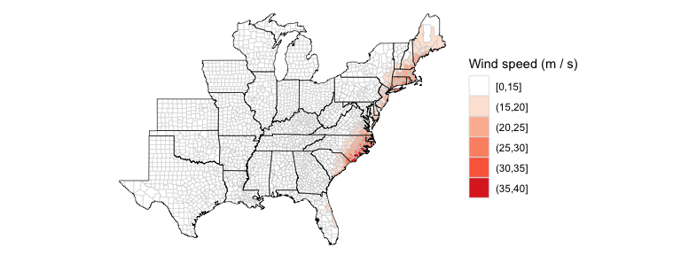

```r
map_wind(floyd_winds)
```

## Further functionality

### Modeling winds at other grid points

You can input the track for any Atlantic Basin tropical storm into `get_grid_winds`, as long as you convert it to meet the following format requirements:

- Is a dataframe of class `tbl_df` (you can use the `tbl_df` function from `dplyr` to do this)
- Has the following columns:
  - `date`: A character vector with date and time (in UTC), expressed as YYYYMMDDHHMM.
  - `latitude`: A numeric vector with latitude in decimal degrees.
  - `longitude`: A numeric vector with longitude in decimal degrees.
  - `wind`: A numeric vector with maximum storm wind speed in knots, representing maximum 10-m 1-minute sustained wind

For the grid point locations at which to model, you can input a dataframe with grid points anywhere in the world. For example, you may want to map wind speeds for Hurricane Katrina by census tract in Orleans Parish, LA. The following code shows how a user could do that with the `stormwindmodel` package. Other vignettes with this package give examples of how to do this in places other than the United States.

First, the `tigris` package can be used to pull US Census tract shapefiles for a county. You can use the following code to pull these census tract file shapefiles for Orleans Parish in Louisiana:

```r
library(tigris)
new_orleans <- tracts(state = "LA", county = c("Orleans")) %>%
  mutate(glandsea = ALAND > AWATER)
```

This data includes columns with the area of land and area of water in each census tract, so we can use that to create a `glandsea` column, using the rubric that the tract is overland if its land area is greater than its water area and over water if not.

This shapefile gives the polygon for each census tract. You can use the `st_centroid` function from the `sf` package to determine the location of the center of each census tract:

```r
library(sf)
new_orleans_tract_centers <- st_centroid(new_orleans)
head(new_orleans_tract_centers)
```

```
## Simple feature collection with 6 features and 13 fields
## Geometry type: POINT
## Dimension:     XY
## Bounding box:  xmin: -90.12008 ymin: 29.91933 xmax: -89.91693 ymax: 30.0401
## Geodetic CRS:  NAD83
##    STATEFP COUNTYFP TRACTCE       GEOID  NAME           NAMELSAD MTFCC FUNCSTAT
## 2       22      071  001747 22071001747 17.47 Census Tract 17.47 G5020        S
## 3       22      071  001750 22071001750 17.50 Census Tract 17.50 G5020        S
## 31      22      071  000800 22071000800     8     Census Tract 8 G5020        S
## 32      22      071  003600 22071003600    36    Census Tract 36 G5020        S
## 33      22      071  011400 22071011400   114   Census Tract 114 G5020        S
## 47      22      071  008600 22071008600    86    Census Tract 86 G5020        S
##      ALAND AWATER    INTPTLAT     INTPTLON                   geometry glandsea
## 2  7166914 344001 +30.0414373 -089.9549478  POINT (-89.95393 30.0401)     TRUE
## 3  1437944 166340 +30.0384832 -089.9176831 POINT (-89.91693 30.03769)     TRUE
## 31  602953      0 +29.9595871 -090.0198758 POINT (-90.01988 29.95959)     TRUE
## 32  385316      0 +29.9781089 -090.0736169 POINT (-90.07362 29.97811)     TRUE
## 33  468065      0 +29.9193262 -090.1200776 POINT (-90.12008 29.91933)     TRUE
## 47  329060      0 +29.9448184 -090.0896678 POINT (-90.08967 29.94482)     TRUE
```

With some cleaning, you can get this data to the format required for the `get_grid_winds` function. In particular, you should add the geo id from the original shapefiles as the grid id, as this will help you map the modeled wind results. You can also extract the latitude and longitude from the geometry of the `sf` object and put them in separate columns, as needed for the wind modeling code:

```r
new_orleans_tract_centers2 <- new_orleans_tract_centers %>%
  mutate(glon = unlist(map(.$geometry, 1)),
         glat = unlist(map(.$geometry, 2))) %>%
  rename(gridid = GEOID) %>%
  st_drop_geometry() %>%
  select(gridid, glat, glon, glandsea)
head(new_orleans_tract_centers2)
```

```
##         gridid     glat      glon glandsea
## 2  22071001747 30.04010 -89.95393     TRUE
## 3  22071001750 30.03769 -89.91693     TRUE
## 31 22071000800 29.95959 -90.01988     TRUE
## 32 22071003600 29.97811 -90.07362     TRUE
## 33 22071011400 29.91933 -90.12008     TRUE
## 47 22071008600 29.94482 -90.08967     TRUE
```

Here is a map of the census tracts, with the center point of each shown with a red dot:

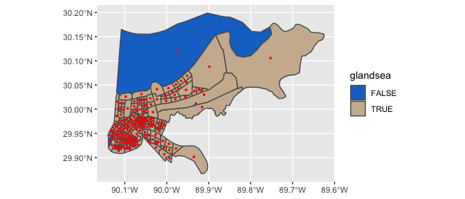

```r
library(ggplot2)
ggplot() +
  geom_sf(data = new_orleans, aes(fill = glandsea)) +
  geom_sf(data = new_orleans_tract_centers, color = "red", size = 0.6) +
  scale_fill_manual(values = c("dodgerblue3", "bisque3"))
```

Since the `new_orleans_tract_centers2` is now in the appropriate format to use with the `stormwindmodel` functions, you can input it directly into `get_grid_winds` to model the winds from Hurricane Katrina at each census tract center:

```r
new_orleans_tracts_katrina <- get_grid_winds(hurr_track = katrina_tracks,
                                             grid_df = new_orleans_tract_centers2)
head(new_orleans_tracts_katrina)
```

```
## # A tibble: 6 × 6
##   gridid      date_time_max_wind  vmax_sust vmax_gust sust_dur gust_dur
##   <chr>       <dttm>                  <dbl>     <dbl>    <dbl>    <dbl>
## 1 22071001747 2005-08-29 13:30:00      39.9      59.5      690      690
## 2 22071001750 2005-08-29 13:30:00      41.3      61.5      690      690
## 3 22071000800 2005-08-29 13:30:00      39.2      58.5      705      705
## 4 22071003600 2005-08-29 13:30:00      37.3      55.6      690      690
## 5 22071011400 2005-08-29 13:30:00      36.6      54.6      690      690
## 6 22071008600 2005-08-29 13:30:00      37.3      55.5      675      675
```

To plot these modeled winds, you can merge this modeled data back into the “sf” version of the census tract shapefile data, joining by geo identification, and then add to the map. You can show wind speed in this map with color.

```r
new_orleans <- new_orleans %>%
  left_join(new_orleans_tracts_katrina, by = c("GEOID" = "gridid"))
```

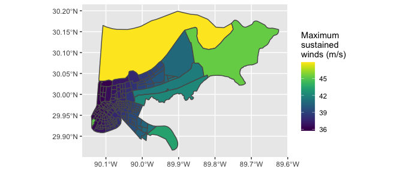

```r
library(viridis)
ggplot() +
  geom_sf(data = new_orleans, aes(fill = vmax_sust)) +
  scale_fill_viridis(name = "Maximum\nsustained\nwinds (m/s)")
```

### Creating time series of winds

So far, we’ve focused on functions that allow you to get an overall summary of how high winds were over the course of a storm at a certain location. There are also functions in the package that allow you to extract more complex versions of the wind data, where there is an estimate for the winds at each location at each time point along the storm’s interpolated track (by default, every 15 minutes). This can allow you to create time series of how winds evolved over the course of the storm at each location you are modeling.

For example, you can use `calc_grid_winds` to calculate the full time series of winds during Hurricane Floyd at the US county centers in the eastern US:

```r
data("floyd_tracks")
data("county_points")

floyd_timeseries_winds <- calc_grid_winds(hurr_track = floyd_tracks,
                                          grid_df = county_points)
str(floyd_timeseries_winds)
```

```
## List of 3
##  $ vmax_sust             : num [1:1129, 1:2396] 0 0 0 0 0 0 0 0 0 0 ...
##   ..- attr(*, "dimnames")=List of 2
##   .. ..$ : chr [1:1129] "1999-09-07 18:00:00" "1999-09-07 18:15:00" "1999-09-07 18:30:00" "1999-09-07 18:45:00" ...
##   .. ..$ : chr [1:2396] "01001" "01003" "01005" "01007" ...
##  $ distance_from_storm   : num [1:1129, 1:2396] 4582 4575 4569 4563 4557 ...
##   ..- attr(*, "dimnames")=List of 2
##   .. ..$ : chr [1:1129] "1999-09-07 18:00:00" "1999-09-07 18:15:00" "1999-09-07 18:30:00" "1999-09-07 18:45:00" ...
##   .. ..$ : chr [1:2396] "01001" "01003" "01005" "01007" ...
##  $ surface_wind_direction: num [1:1129, 1:2396] NA NA NA NA NA NA NA NA NA NA ...
##   ..- attr(*, "dimnames")=List of 2
##   .. ..$ : chr [1:1129] "1999-09-07 18:00:00" "1999-09-07 18:15:00" "1999-09-07 18:30:00" "1999-09-07 18:45:00" ...
##   .. ..$ : chr [1:2396] "01001" "01003" "01005" "01007" ...
```

This creates an array of three matrices, each with the same dimensions. There is one matrix each for maximum sustained winds at that time point in that location (`vmax_sust`), distance between the grid point and the storm’s center at that time (`distance_from_storm`), and the surface wind direction (if the storm was within a certain distance of the storm, otherwise this value will be set as missing) (`surface_wind_direction`). For each of these matrices, the rownames give the date and time of the estimate and the column names give the grid ID (in this case, the county FIPS code). Here’s an example of a subset of the wind matrix for some counties in North Carolina around the time of highest winds in the state:

```r
floyd_timeseries_winds[["vmax_sust"]][830:840, 1400:1410]
```

```
##                        37021    37023     37025    37027    37029    37031
## 1999-09-16 09:15:00 5.721721 7.656765 11.278906 7.828813 15.66919 33.99837
## 1999-09-16 09:30:00 5.677085 7.608157 11.178747 7.791503 16.19404 35.37429
## 1999-09-16 09:45:00 5.627172 7.551176 11.064167 7.745253 16.72975 36.38580
## 1999-09-16 10:00:00 5.572254 7.486155 10.935876 7.690341 17.27607 36.81890
## 1999-09-16 10:15:00 5.512812 7.413697 10.794986 7.627322 17.83243 36.58173
## 1999-09-16 10:30:00 5.448878 7.333884 10.641940 7.556236 18.39941 35.78599
## 1999-09-16 10:45:00 5.380940 7.247366 10.477972 7.477700 18.97723 34.61118
## 1999-09-16 11:00:00 5.309160 7.154417 10.303830 7.391960 19.56759 33.23651
## 1999-09-16 11:15:00 5.233966 7.055642 10.120717 7.299606 20.17298 31.79015
## 1999-09-16 11:30:00 5.155697 6.951551  9.929707 7.201140 20.79812 30.34873
## 1999-09-16 11:45:00 5.074517 6.842460  9.731617 7.096869 21.45172 28.95170
##                        37033    37035    37037    37039    37041
## 1999-09-16 09:15:00 12.71196 8.765115 15.93226 3.551014 18.12575
## 1999-09-16 09:30:00 12.82888 8.709713 15.96710 3.516742 18.68154
## 1999-09-16 09:45:00 12.92891 8.644067 15.97514 3.479997 19.24211
## 1999-09-16 10:00:00 13.01129 8.568563 15.95551 3.440952 19.80637
## 1999-09-16 10:15:00 13.07562 8.483898 15.90790 3.399939 20.37308
## 1999-09-16 10:30:00 13.12089 8.390207 15.83121 3.356923 20.94272
## 1999-09-16 10:45:00 13.14683 8.288257 15.72561 3.312218 21.51651
## 1999-09-16 11:00:00 13.15276 8.178414 15.59088 3.265877 22.04891
## 1999-09-16 11:15:00 13.13849 8.061413 15.42785 3.218149 22.57024
## 1999-09-16 11:30:00 13.10382 7.937893 15.23753 3.169215 23.12579
## 1999-09-16 11:45:00 13.04836 7.808279 15.02100 3.119113 23.75651
```

You can extract from this dataset by timepoint, if you want to see a snapshot of modeled winds at a specific time, or extract by grid point, if you want to see how winds changed over the course of the storm at that time point. For example, here is the code to extract and show modeled wind at the population mean center of Dare County, NC (FIPS: 37055) throughout Hurricane Floyd:

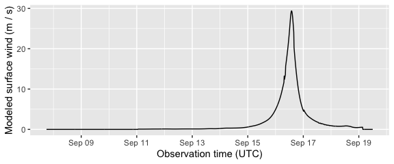

```r
library(lubridate)
dare_winds <- floyd_timeseries_winds[["vmax_sust"]][ , "37055"] %>%
  enframe(name = "date", value = "windspeed") %>%
  mutate(date = ymd_hms(date))

ggplot(dare_winds, aes(x = date, y = windspeed)) +
  geom_line() +
  xlab("Observation time (UTC)") +
  ylab("Modeled surface wind (m / s)")
```

### Options for mapping county-level winds

There are a number of options when mapping wind speeds using `map_wind`.

First, you can use the `add_storm_track` function to add the storm track to the map. This function inputs one dataframe with tracking data (the `floyd_tracks` example data that comes with the package in this case) as well as the plot object created using `map_wind`, which is input using the `plot_object` argument. In this example code, we’ve first created the base map of modeled winds in each county using `map_wind`. We then input that, along with Floyd’s track data, into `add_storm_track` to create a map with both winds and the storm tracks:

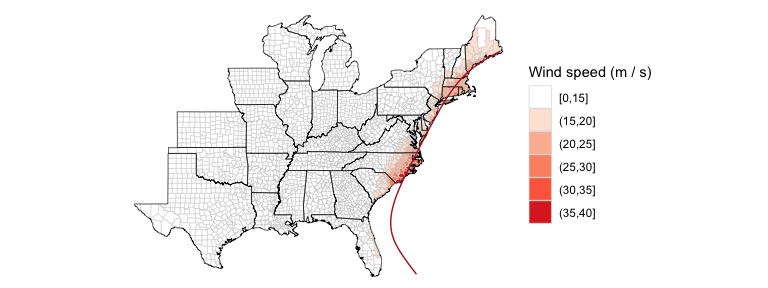

```r
floyd_map <- map_wind(floyd_winds)
add_storm_track(floyd_tracks, plot_object = floyd_map)
```

You can choose whether to map sustained or gust winds (`value`, which can take “vmax_gust” or “vmax_sust”), as well as the unit to use for wind speed (`wind_metric`, which can take values of “mps” for meters per second [the default] or “knots”). For example, you can modeled gust wind speeds in knots during Hurricane Floyd using:

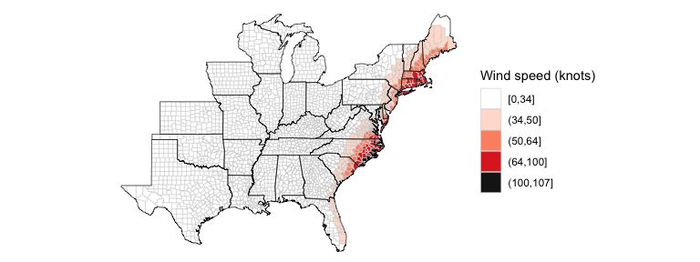

```r
map_wind(floyd_winds, value = "vmax_gust", wind_metric = "knots")
```

Finally, you can map a binary classification of counties with winds at or above a certain break point. For example, to map counties with sustained wind at or above 34 knots during Hurricane Floyd, you can run:

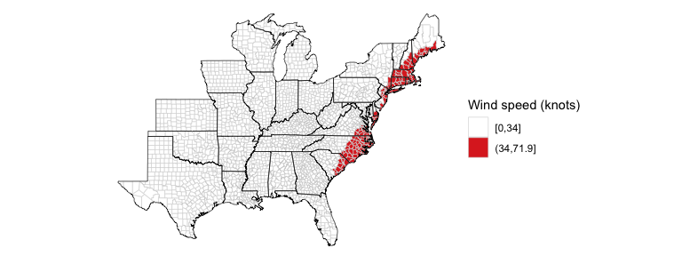

```r
map_wind(floyd_winds, value = "vmax_sust", wind_metric = "knots", break_point = 34)
```

## Tracks data

You can get an R version of the hurricane best tracks data for Atlantic basin storms from 1988 to 2018 through the `hurricaneexposuredata` package (in development on GitHub). For more information, see [the GitHub repository for that package](https://github.com/geanders/hurricaneexposuredata). You can also get best tracks data for tropical cyclones worldwide from IBTrACS.

# References

Willoughby, HE, RWR Darling, and ME Rahn. 2006. “Parametric Representation of the Primary Hurricane Vortex. Part II: A New Family of Sectionally Continuous Profiles.” *Monthly Weather Review* 134 (4): 1102–20.